# Random Forests

*Random forests* are a modification of bagged decision trees that build a large collection of *de-correlated* trees to further improve predictive performance. They have become a very popular “out-of-the-box” or “off-the-shelf” learning algorithm that enjoys good predictive performance with relatively little hyperparameter tuning. Many modern implementations of random forests exist; however, Leo Breiman’s algorithm (Breiman 2001) has largely become the authoritative procedure. This module will cover the fundamentals of random forests.

# Prerequisites

This module leverages the following packages. Some of these packages play a supporting role; however, the emphasis is on how to implement random forests with the **ranger** (Wright and Ziegler 2017) and **h2o** packages.

```r
# Helper packages
library(dplyr)    # for data wrangling
library(ggplot2)  # for awesome graphics

# Modeling packages
library(ranger)   # a c++ implementation of random forest
library(h2o)      # a java-based implementation of random forest
library(rsample)  # resampling procedures
```

We’ll continue working with the `ames_train` data set to illustrate the main concepts.

```r
# create Ames training data
ames <- AmesHousing::make_ames()
set.seed(123)
ames <- AmesHousing::make_ames()
split  <- initial_split(ames, prop = 0.7, strata = "Sale_Price")
ames_train  <- training(split)
```

# Extending bagging

Random forests are built using the same fundamental principles as decision trees and bagging. Bagging trees introduces a random component into the tree building process by building many trees on bootstrapped copies of the training data. Bagging then aggregates the predictions across all the trees; this aggregation reduces the variance of the overall procedure and results in improved predictive performance. However, as we saw in the last module, simply bagging trees results in tree correlation that limits the effect of variance reduction.

Random forests help to reduce tree correlation by injecting more randomness into the tree-growing process.[^1] More specifically, while growing a decision tree during the bagging process, random forests perform *split-variable randomization* where each time a split is to be performed, the search for the split variable is limited to a random subset of $m_{try}$ of the original $p$ features. Typical default values are $m_{try} = \frac{p}{3}$ (regression) and $m_{try} = \sqrt{p}$ (classification) but this should be considered a tuning parameter.

The basic algorithm for a regression or classification random forest can be generalized as follows:

```
1.  Given a training data set
2.  Select number of trees to build (n_trees)
3.  for i = 1 to n_trees do
4.  |  Generate a bootstrap sample of the original data
5.  |  Grow a regression/classification tree to the bootstrapped data
6.  |  for each split do
7.  |  | Select m_try variables at random from all p variables
8.  |  | Pick the best variable/split-point among the m_try
9.  |  | Split the node into two child nodes
10. |  end
11. | Use typical tree model stopping criteria to determine when a
    | tree is complete (but do not prune)
12. end
13. Output ensemble of trees
```

> *Pro Tip:* *When $m_{try} = p$, the algorithm is equivalent to bagging decision trees.*

Since the algorithm randomly selects a bootstrap sample to train on *and* a random sample of features to use at each split, a more diverse set of trees is produced which tends to lessen tree correlation beyond bagged trees and often dramatically increase predictive power.

# Out-of-the-box performance

Random forests have become popular because they tend to provide very good out-of-the-box performance. Although they have several hyperparameters that can be tuned, the default values tend to produce good results. Moreover, Probst, Bischl, and Boulesteix (2018) illustrated that among the more popular machine learning algorithms, random forests have the least variability in their prediction accuracy when tuning.

For example, if we train a random forest model[^2] with all hyperparameters set to their default values, we get an OOB RMSE that is comparable to some of the best model’s we’ve run thus far (without any tuning).

*Pro Tip:* *By default, **ranger** sets the `mtry` parameter to $\text{floor}\big(\sqrt{\texttt{number of features}}\big)$; however, for regression problems the preferred `mtry` to start with is $\text{floor}\big(\frac{\texttt{number of features}}{3}\big)$. We also set `respect.unordered.factors = "order"`. This specifies how to treat unordered factor variables and we recommend setting this to “order” (see Friedman, Hastie, and Tibshirani (2001) Section 9.2.4 for details).*

```r
# number of features
n_features <- length(setdiff(names(ames_train), "Sale_Price"))

# train a default random forest model
ames_rf1 <- ranger(
  Sale_Price ~ .,
  data = ames_train,
  mtry = floor(n_features / 3),
  respect.unordered.factors = "order",
  seed = 123
)

# get OOB RMSE
(default_rmse <- sqrt(ames_rf1$prediction.error))
```

```
[1] 26042.77
```

# Hyperparameters

Although random forests perform well out-of-the-box, there are several tunable hyperparameters that we should consider when training a model. Although we briefly discuss the main hyperparameters, Probst, Wright, and Boulesteix (2019) provide a much more thorough discussion. The main hyperparameters to consider include:

## Number of trees

The first consideration is the number of trees within your random forest. Although not technically a hyperparameter, the number of trees needs to be sufficiently large to stabilize the error rate. A good rule of thumb is to start with 10 times the number of features as illustrated below); however, as you adjust other hyperparameters such as $m_{try}$ and node size, more or fewer trees may be required. More trees provide more robust and stable error estimates and variable importance measures; however, the impact on computation time increases linearly with the number of trees.

> *Pro Tip:* *Start with $p \times 10$ trees and adjust as necessary*

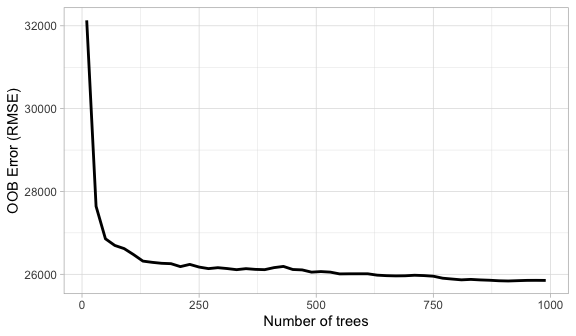

## $m_{try}$

The hyperparameter that controls the split-variable randomization feature of random forests is often referred to as $m_{try}$ and it helps to balance low tree correlation with reasonable predictive strength. With regression problems the default value is often $m_{try} = \frac{p}{3}$ and for classification $m_{try} = \sqrt{p}$. However, when there are fewer relevant predictors (e.g., noisy data) a higher value of $m_{try}$ tends to perform better because it makes it more likely to select those features with the strongest signal. When there are many relevant predictors, a lower $m_{try}$ might perform better.

> *Pro Tip:* *Start with five evenly spaced values of $m_{try}$ across the range 2–$p$ centered at the recommended default as illustrated below. For the Ames data, an mtry value slightly lower (21) than the default (26) improves performance.*

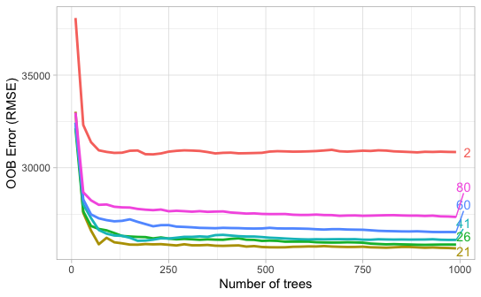

## Tree complexity

Random forests are built on individual decision trees; consequently, most random forest implementations have one or more hyperparameters that allow us to control the depth and complexity of the individual trees. This will often include hyperparameters such as node size, max depth, max number of terminal nodes, or the required node size to allow additional splits. Node size is probably the most common hyperparameter to control tree complexity and most implementations use the default values of one for classification and five for regression as these values tend to produce good results (Dı'az-Uriarte and De Andres 2006; Goldstein, Polley, and Briggs 2011). However, Segal (2004) showed that if your data has many noisy predictors and higher $m_{try}$ values are performing best, then performance may improve by increasing node size (i.e., decreasing tree depth and complexity). Moreover, if computation time is a concern then you can often decrease run time substantially by increasing the node size and have only marginal impacts to your error estimate as illustrated below.

> *Pro Tip:* *When adjusting node size start with three values between 1–10 and adjust depending on impact to accuracy and run time. Increasing node size to reduce tree complexity will often have a larger impact on computation speed (right) than on your error estimate.*

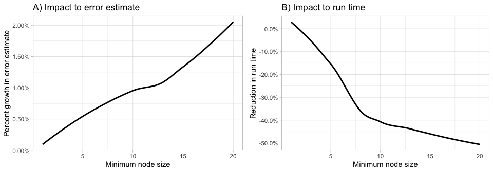

## Sampling scheme

The default sampling scheme for random forests is bootstrapping where 100% of the observations are sampled with replacement (in other words, each bootstrap copy has the same size as the original training data); however, we can adjust both the sample size and whether to sample with or without replacement. The sample size parameter determines how many observations are drawn for the training of each tree. Decreasing the sample size leads to more diverse trees and thereby lower between-tree correlation, which can have a positive effect on the prediction accuracy. Consequently, if there are a few dominating features in your data set, reducing the sample size can also help to minimize between-tree correlation.

Also, when you have many categorical features with a varying number of levels, sampling with replacement can lead to biased variable split selection (Janitza, Binder, and Boulesteix 2016; Strobl et al. 2007). Consequently, if you have categories that are not balanced, sampling without replacement provides a less biased use of all levels across the trees in the random forest.

> *Pro Tip:* *Assess 3–4 values of sample sizes ranging from 25%–100% and if you have unbalanced categorical features try sampling without replacement. The Ames data has several imbalanced categorical features such as neighborhood, zoning, overall quality, and more. Consequently, sampling without replacement appears to improve performance as it leads to less biased split variable selection and more uncorrelated trees.*

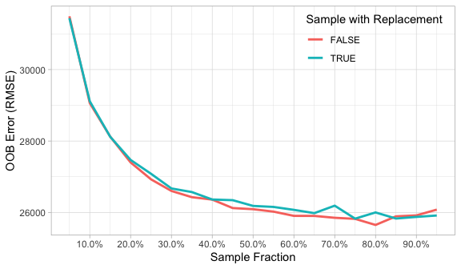

## Split rule

Recall the default splitting rule during random forests tree building consists of selecting, out of all splits of the (randomly selected $m_{try}$) candidate variables, the split that minimizes the Gini impurity (in the case of classification) and the SSE (in case of regression). However, Strobl et al. (2007) illustrated that these default splitting rules favor the selection of features with many possible splits (e.g., continuous variables or categorical variables with many categories) over variables with fewer splits (the extreme case being binary variables, which have only one possible split). *Conditional inference trees* (Hothorn, Hornik, and Zeileis 2006) implement an alternative splitting mechanism that helps to reduce this variable selection bias.[^3] However, ensembling conditional inference trees has yet to be proven superior with regards to predictive accuracy and they take a lot longer to train.

To increase computational efficiency, splitting rules can be randomized where only a random subset of possible splitting values is considered for a variable (Geurts, Ernst, and Wehenkel 2006). If only a single random splitting value is randomly selected then we call this procedure *extremely randomized trees*. Due to the added randomness of split points, this method tends to have no improvement, or often a negative impact, on predictive accuracy.

Regarding runtime, extremely randomized trees are the fastest as the cutpoints are drawn completely randomly, followed by the classical random forest, while for conditional inference forests the runtime is the largest (Probst, Wright, and Boulesteix 2019).

> *Pro Tip:* *If you need to increase computation time significantly try completely randomized trees; however, be sure to assess predictive accuracy to traditional split rules as this approach often has a negative impact on your loss function.*

# Tuning strategies

## Cartesian grid search

As we introduce more complex algorithms with greater number of hyperparameters, we should become more strategic with our tuning strategies. One way to become more strategic is to consider how we proceed through our grid search. Up to this point, all our grid searches have been *full Cartesian grid searches* where we assess every combination of hyperparameters of interest. We could continue to do the same; for example, the next code block searches across 120 combinations of hyperparameter settings.

> *Warning:* *This grid search takes approximately 2 minutes.*

```r
# create hyperparameter grid
hyper_grid <- expand.grid(
  mtry = floor(n_features * c(.05, .15, .25, .333, .4)),
  min.node.size = c(1, 3, 5, 10),
  replace = c(TRUE, FALSE),
  sample.fraction = c(.5, .63, .8),
  rmse = NA
)

# execute full cartesian grid search
for(i in seq_len(nrow(hyper_grid))) {
  # fit model for ith hyperparameter combination
  fit <- ranger(
    formula         = Sale_Price ~ .,
    data            = ames_train,
    num.trees       = n_features * 10,
    mtry            = hyper_grid$mtry[i],
    min.node.size   = hyper_grid$min.node.size[i],
    replace         = hyper_grid$replace[i],
    sample.fraction = hyper_grid$sample.fraction[i],
    verbose         = FALSE,
    seed            = 123,
    respect.unordered.factors = 'order',
  )
  # export OOB error
  hyper_grid$rmse[i] <- sqrt(fit$prediction.error)
}

# assess top 10 models
hyper_grid %>%
  arrange(rmse) %>%
  mutate(perc_gain = (default_rmse - rmse) / default_rmse * 100) %>%
  head(10)
```

|  | mtry | min.node.size | replace | sample.fraction | rmse | perc_gain |
| --- | --- | --- | --- | --- | --- | --- |
| 1 | 20 | 5 | FALSE | 0.8 | 25625.71 | 1.601456 |
| 2 | 26 | 5 | FALSE | 0.8 | 25662.78 | 1.459105 |
| 3 | 12 | 1 | FALSE | 0.8 | 25670.13 | 1.430888 |
| 4 | 26 | 3 | FALSE | 0.8 | 25694.50 | 1.337320 |
| 5 | 20 | 1 | FALSE | 0.8 | 25701.60 | 1.310047 |
| 6 | 20 | 3 | FALSE | 0.8 | 25716.93 | 1.251167 |
| 7 | 12 | 3 | FALSE | 0.8 | 25722.90 | 1.228250 |
| 8 | 26 | 10 | FALSE | 0.8 | 25758.07 | 1.093201 |
| 9 | 12 | 5 | FALSE | 0.8 | 25767.55 | 1.056805 |
| 10 | 26 | 1 | FALSE | 0.8 | 25769.49 | 1.049352 |

If we look at the results we see that the top 10 models are all around an RMSE of 25000 (a 1.0%–1.6% improvement over our baseline model). In these results, the default `mtry` value of $\left \lfloor{\frac{\texttt{# features}}{3}}\right \rfloor = 26$ is nearly sufficient and smaller node sizes (deeper trees) perform best. What stands out the most is that taking less than 100% sample rate and sampling without replacement consistently performs best. Sampling less than 100% adds additional randomness in the procedure, which helps to further de-correlate the trees. Sampling without replacement likely improves performance because this data has a lot of high cardinality categorical features that are imbalanced.

## Random grid search

However, as we add more hyperparameters and values to search across and as our data sets become larger, you can see how a full Cartesian search can become exhaustive and computationally expensive. In addition to full Cartesian search, the **h2o** package provides a *random grid search* that allows you to jump from one random combination to another and it also provides *early stopping* rules that allow you to stop the grid search once a certain condition is met (e.g., a certain number of models have been trained, a certain runtime has elapsed, or the accuracy has stopped improving by a certain amount). Although using a random discrete search path will likely not find the optimal model, it typically does a good job of finding a very good model.

To fit a random forest model with **h2o**, we first need to initiate our **h2o** session.

```r
h2o.no_progress()
h2o.init(max_mem_size = "5g")
```

```
 Connection successful!

R is connected to the H2O cluster:
    H2O cluster uptime:         3 days 19 hours
    H2O cluster timezone:       America/New_York
    H2O data parsing timezone:  UTC
    H2O cluster version:        3.30.0.1
    H2O cluster version age:    2 months and 14 days
    H2O cluster name:           H2O_started_from_R_b294776_uwc322
    H2O cluster total nodes:    1
    H2O cluster total memory:   3.28 GB
    H2O cluster total cores:    8
    H2O cluster allowed cores:  8
    H2O cluster healthy:        TRUE
    H2O Connection ip:          localhost
    H2O Connection port:        54321
    H2O Connection proxy:       NA
    H2O Internal Security:      FALSE
    H2O API Extensions:         Amazon S3, XGBoost, Algos, AutoML, Core V3, TargetEncoder, Core V4
    R Version:                  R version 4.0.0 (2020-04-24)
```

Next, we need to convert our training and test data sets to objects that **h2o** can work with.

```r
# convert training data to h2o object
train_h2o <- as.h2o(ames_train)

# set the response column to Sale_Price
response <- "Sale_Price"

# set the predictor names
predictors <- setdiff(colnames(ames_train), response)
```

The following fits a default random forest model with **h2o** to illustrate that our baseline results ($\text{OOB RMSE} = 26,079$) are very similar to the baseline **ranger** model we fit earlier.

```r
h2o_rf1 <- h2o.randomForest(
    x = predictors,
    y = response,
    training_frame = train_h2o,
    ntrees = n_features * 10,
    seed = 123
)

h2o_rf1
```

```
Model Details:
==============

H2ORegressionModel: drf
Model ID:  DRF_model_R_1592147973662_2
Model Summary:
```

|  | number_of_trees | number_of_internal_trees | model_size_in_bytes | min_depth | max_depth | mean_depth | min_leaves | max_leaves | mean_leaves |
| --- | --- | --- | --- | --- | --- | --- | --- | --- | --- |
| 1 | 800 | 800 | 12392979 | 20 | 20 | 20.00000 | 1130 | 1291 | 1227.79750 |

```
H2ORegressionMetrics: drf
** Reported on training data. **
** Metrics reported on Out-Of-Bag training samples **

MSE:  680109951
RMSE:  26078.92
MAE:  15451.62
RMSLE:  0.1349113
Mean Residual Deviance :  680109951
```

To execute a grid search in **h2o** we need our hyperparameter grid to be a list. For example, the following code searches a larger grid space than before with a total of 240 hyperparameter combinations. We then create a random grid search strategy that will stop if none of the last 10 models have managed to have a 0.1% improvement in MSE compared to the best model before that. If we continue to find improvements then we cut the grid search off after 300 seconds (5 minutes).

```r
# hyperparameter grid
hyper_grid <- list(
  mtries = floor(n_features * c(.05, .15, .25, .333, .4)),
  min_rows = c(1, 3, 5, 10),
  max_depth = c(10, 20, 30),
  sample_rate = c(.55, .632, .70, .80)
)

# random grid search strategy
search_criteria <- list(
  strategy = "RandomDiscrete",
  stopping_metric = "mse",
  stopping_tolerance = 0.001,   # stop if improvement is < 0.1%
  stopping_rounds = 10,         # over the last 10 models
  max_runtime_secs = 60*5      # or stop search after 5 min.
)
```

> *Warning:* *This grid search takes 5 minutes.*

```r
# perform grid search
random_grid <- h2o.grid(
  algorithm = "randomForest",
  grid_id = "rf_random_grid",
  x = predictors,
  y = response,
  training_frame = train_h2o,
  hyper_params = hyper_grid,
  ntrees = n_features * 10,
  seed = 123,
  stopping_metric = "RMSE",
  stopping_rounds = 10,           # stop if last 10 trees added
  stopping_tolerance = 0.005,     # don't improve RMSE by 0.5%
  search_criteria = search_criteria
)
```

```r
# collect the results and sort by our model performance metric
# of choice
random_grid_perf <- h2o.getGrid(
  grid_id = "rf_random_grid",
  sort_by = "mse",
  decreasing = FALSE
)
random_grid_perf
```

```
H2O Grid Details
================

Grid ID: rf_random_grid
Used hyper parameters:
  -  max_depth
  -  min_rows
  -  mtries
  -  sample_rate
Number of models: 153
Number of failed models: 0

Hyper-Parameter Search Summary: ordered by increasing mse
```

|  | max_depth | min_rows | mtries | sample_rate | model_ids | mse |
| --- | --- | --- | --- | --- | --- | --- |
| 1 | 20 | 1.0 | 32 | 0.8 | rf_random_grid_model_27 | 6.577100563897063E8 |
| 2 | 30 | 1.0 | 20 | 0.8 | rf_random_grid_model_107 | 6.63865563231841E8 |
| 3 | 30 | 1.0 | 26 | 0.8 | rf_random_grid_model_151 | 6.730703680875415E8 |
| 4 | 20 | 3.0 | 26 | 0.632 | rf_random_grid_model_45 | 7.077776644144523E8 |
| 5 | 30 | 1.0 | 20 | 0.632 | rf_random_grid_model_81 | 7.082535774579861E8 |

|  | max_depth | min_rows | mtries | sample_rate | model_ids | mse |
| --- | --- | --- | --- | --- | --- | --- |
| 148 | 30 | 10.0 | 4 | 0.632 | rf_random_grid_model_44 | 1.0542483856550839E9 |
| 149 | 30 | 10.0 | 4 | 0.8 | rf_random_grid_model_30 | 1.0551865623377068E9 |
| 150 | 10 | 10.0 | 4 | 0.632 | rf_random_grid_model_5 | 1.0585006124906375E9 |
| 151 | 10 | 10.0 | 4 | 0.8 | rf_random_grid_model_127 | 1.0639923126477883E9 |
| 152 | 20 | 10.0 | 4 | 0.7 | rf_random_grid_model_12 | 1.0784759533587E9 |
| 153 | 30 | 10.0 | 4 | 0.55 | rf_random_grid_model_48 | 1.122836903932838E9 |

# Feature interpretation

Computing feature importance and feature effects for random forests follow the same procedure as discussed in the bagging module. However, in addition to the impurity-based measure of feature importance where we base feature importance on the average total reduction of the loss function for a given feature across all trees, random forests also typically include a *permutation-based* importance measure. In the permutation-based approach, for each tree, the OOB sample is passed down the tree and the prediction accuracy is recorded. Then the values for each variable (one at a time) are randomly permuted and the accuracy is again computed. The decrease in accuracy as a result of this randomly shuffling of feature values is averaged over all the trees for each predictor. The variables with the largest average decrease in accuracy are considered most important.

For example, we can compute both measures of feature importance with **ranger** by setting the `importance` argument.

> *Pro Tip:* *For **ranger**, once you’ve identified the optimal parameter values from the grid search, you will want to re-run your model with these hyperparameter values. You can also crank up the number of trees, which will help create more stables values of variable importance.*

```r
# re-run model with impurity-based variable importance
rf_impurity <- ranger(
  formula = Sale_Price ~ .,
  data = ames_train,
  num.trees = 2000,
  mtry = 32,
  min.node.size = 1,
  sample.fraction = .80,
  replace = FALSE,
  importance = "impurity",
  respect.unordered.factors = "order",
  verbose = FALSE,
  seed  = 123
)

# re-run model with permutation-based variable importance
rf_permutation <- ranger(
  formula = Sale_Price ~ .,
  data = ames_train,
  num.trees = 2000,
  mtry = 32,
  min.node.size = 1,
  sample.fraction = .80,
  replace = FALSE,
  importance = "permutation",
  respect.unordered.factors = "order",
  verbose = FALSE,
  seed  = 123
)
```

The resulting VIPs are displayed below. Typically, you will not see the same variable importance order between the two options; however, you will often see similar variables at the top of the plots (and also the bottom). Consequently, in this example, we can comfortably state that there appears to be enough evidence to suggest that three variables stand out as most influential:

- `Overall_Qual`
- `Gr_Liv_Area`
- `Neighborhood`

Looking at the next ~10 variables in both plots, you will also see some commonality in influential variables (e.g., `Garage_Cars`, `Exter_Qual`, `Bsmt_Qual`, and `Year_Built`).

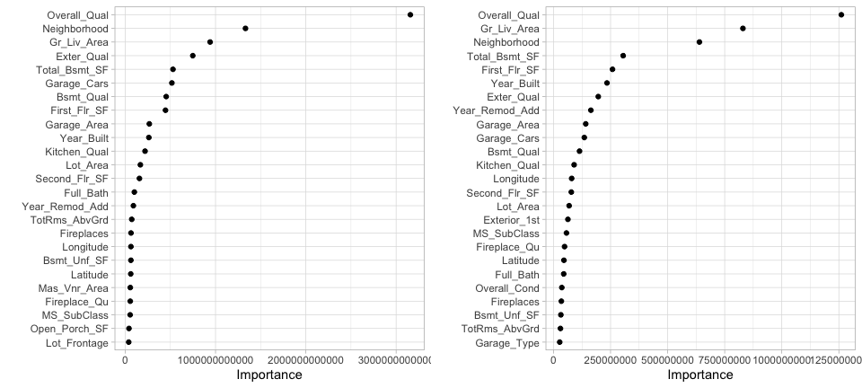

```r
p1 <- vip::vip(rf_impurity, num_features = 25, geom = "point")
p2 <- vip::vip(rf_permutation, num_features = 25, geom = "point")

gridExtra::grid.arrange(p1, p2, nrow = 1)
```

# Final thoughts

Random forests provide a very powerful out-of-the-box algorithm that often has great predictive accuracy. They come with all the benefits of decision trees (with the exception of surrogate splits) and bagging but greatly reduce instability and between-tree correlation. And due to the added split variable selection attribute, random forests are also faster than bagging as they have a smaller feature search space at each tree split. However, random forests will still suffer from slow computational speed as your data sets get larger but, similar to bagging, the algorithm is built upon independent steps, and most modern implementations (e.g., **ranger**, **h2o**) allow for parallelization to improve training time.

# Python

The following resources provide detailed examples of performing random forests with Python and Scikit Learn:

- Jordan Crouser’s [lab notebook](http://www.science.smith.edu/~jcrouser/SDS293/labs/lab14-py.html) on random forests for Smith College Machine Learning course (sections 8.3.3).
- Machine Learning Mastery’s post on [How to Develop a Random Forest Ensemble in Python](https://machinelearningmastery.com/random-forest-ensemble-in-python/).
- Chapter 7 of [Hands-On Machine Learning with Scikit-Learn, Keras, and TensorFlow](https://www.amazon.com/Hands-Machine-Learning-Scikit-Learn-TensorFlow-dp-1492032646/dp/1492032646/ref=dp_ob_title_bk) and the accompanying publicly available [jupyter notebook](https://github.com/ageron/handson-ml2/blob/master/07_ensemble_learning_and_random_forests.ipynb) regarding random forests (code chunks 15-24).
- Chris Albon’s [numerous tutorials](https://chrisalbon.com/) on random forests (look for the *Trees and Forests* section).

# Exercises

Using the Boston housing data set from the pdp package, where the response feature is the median value of homes within a census tract (`cmedv`):

1. Apply a default random forest model with the same features you used in the bagging module. How does the out-of-the-box random forest model perform compared to the bagging module?
2. Assess the number of trees in your random forest model.
   - How many trees are applied?
   - Was it enough to stabilize the loss function or do you need to add more?
3. Perform a full cartesian grid search across various values of:
   - $m_{try}$
   - tree complexity (i.e. max depth, node size)
   - sampling scheme
4. How long did the above grid search take? Which model gave the best performance?
5. Now run a random grid search across the same hyperparameter grid but restrict the time or number of models to run to 50% of the models ran in the full cartesian. How does the random grid search results compare?
6. Pick your best random forest model. Which 10 features are considered most influential? Are these the same features that have been influential in previous models?
7. Create partial dependence plots for the top two most influential features. Explain the relationship between the feature and the predicted values.
8. Now perform 1-7 to the Attrition dataset, which is classification model rather than a regression model.
9. **Python challenge**: Repeat the above exercises but using Python and Scikit Learn.

[🏠](https://github.com/misk-data-science/misk-homl)

# References

Breiman, Leo. 2001. “Random Forests.” *Machine Learning* 45 (1). Springer: 5–32.

Dı'az-Uriarte, Ramón, and Sara Alvarez De Andres. 2006. “Gene Selection and Classification of Microarray Data Using Random Forest.” *BMC Bioinformatics* 7 (1). BioMed Central: 3.

Friedman, Jerome, Trevor Hastie, and Robert Tibshirani. 2001. *The Elements of Statistical Learning*. Vol. 1. Springer Series in Statistics New York, NY, USA:

Geurts, Pierre, Damien Ernst, and Louis Wehenkel. 2006. “Extremely Randomized Trees.” *Machine Learning* 63 (1). Springer: 3–42.

Goldstein, Benjamin A, Eric C Polley, and Farren BS Briggs. 2011. “Random Forests for Genetic Association Studies.” *Statistical Applications in Genetics and Molecular Biology* 10 (1). De Gruyter.

Hothorn, Torsten, Kurt Hornik, and Achim Zeileis. 2006. “Unbiased Recursive Partitioning: A Conditional Inference Framework.” *Journal of Computational and Graphical Statistics* 15 (3). Taylor & Francis: 651–74.

Hothorn, Torsten, and Achim Zeileis. 2015. “Partykit: A Modular Toolkit for Recursive Partytioning in R.” *The Journal of Machine Learning Research* 16 (1). JMLR. org: 3905–9.

Janitza, Silke, Harald Binder, and Anne-Laure Boulesteix. 2016. “Pitfalls of Hypothesis Tests and Model Selection on Bootstrap Samples: Causes and Consequences in Biometrical Applications.” *Biometrical Journal* 58 (3). Wiley Online Library: 447–73.

Liaw, Andy, and Matthew Wiener. 2002. “Classification and Regression by randomForest.” *R News* 2 (3): 18–22. https://CRAN.R-project.org/doc/Rnews/.

Probst, Philipp, Bernd Bischl, and Anne-Laure Boulesteix. 2018. “Tunability: Importance of Hyperparameters of Machine Learning Algorithms.” *arXiv Preprint arXiv:1802.09596*.

Probst, Philipp, Marvin N Wright, and Anne-Laure Boulesteix. 2019. “Hyperparameters and Tuning Strategies for Random Forest.” *Wiley Interdisciplinary Reviews: Data Mining and Knowledge Discovery*. Wiley Online Library, e1301.

Segal, Mark R. 2004. “Machine Learning Benchmarks and Random Forest Regression.” *UCSF: Center for Bioinformatics and Molecular Biostatistics*.

Strobl, Carolin, Anne-Laure Boulesteix, Achim Zeileis, and Torsten Hothorn. 2007. “Bias in Random Forest Variable Importance Measures: Illustrations, Sources and a Solution.” *BMC Bioinformatics* 8 (1). BioMed Central: 25.

Wright, Marvin, and Andreas Ziegler. 2017. “Ranger: A Fast Implementation of Random Forests for High Dimensional Data in C++ and R.” *Journal of Statistical Software, Articles* 77 (1): 1–17. https://doi.org/10.18637/jss.v077.i01.

[^1]: See Friedman, Hastie, and Tibshirani (2001) for a mathematical explanation of the tree correlation phenomenon.
[^2]: Here we use the **ranger** package to fit a baseline random forest. It is common for folks to first learn to implement random forests by using the original **randomForest** package (Liaw and Wiener 2002). Although **randomForest** is a great package with many bells and whistles, **ranger** provides a much faster C++ implementation of the same algorithm.
[^3]: Conditional inference trees are available in the **partykit** (Hothorn and Zeileis 2015) and **ranger** packages among others.